# Smoller Brainspan Part 1: GEO Data Overview

Meeta Mistry

Array analysis for Erin Dunn (erindunn@pngu.mgh.harvard.edu) at MGH. Contact Meeta Mistry (mmistry@hsph.harvard.edu) for additional details. Request from client was:

> We want to look at developmental changes in the postmortem human brain using gene expression data from publicly available from microarray studies. We hope to identify gene groups that share a similar trajectory of expression change, and use these groups to then overlay genetic association data. It doesn’t look like BrainCloud is an ideal dataset because of the issues related to the PMI. Given this, I think we should probably focus on BrainSpan and run a parallel set of analyses to see if things look cleaner.

## Workflow:

- grab the BrainSpan data from [GEO](http://www.ncbi.nlm.nih.gov/geo/query/acc.cgi?acc=GSE25219) and metadata
- focus on OFC
- take a quick look at metadata patterns across stage
- re-run the QC on normalized and raw data
- differential expression analysis

## Setup

### Bioconductor and R libraries used

```r
library(ggplot2)
library(gtable)
library(scales)
library(RColorBrewer)
library(GEOquery)
library(affy)
library(arrayQualityMetrics)
library(reshape)
library(xtable)
library(ruv)
library(limma)
library(Biobase)
library(gridExtra)
library(stringr)
library(knitr)
library(png)
library(sva)
library(dplyr)
library(CHBUtils)
```

### Get variables

- get base directory for analyses
- specify data and results directories
- specify column headers used in metadata file

```r
# Setup directory variables
baseDir <- '.'
dataDir <- file.path(baseDir, "data")
metaDir <- file.path(dataDir, "meta")
resultsDir <- file.path(baseDir, "results")
```

## Load the expression data

Using RMA background corrected data, with quantile normalization and log2-transformation. The median of all probe sets within one gene (transcript cluster) was used as the estimate of gene expression. From the supplement ‘…a total of 17,565 mainly protein coding genes were surveyed’

```r
# Load GEO data
gse_gene <- getGEO(filename=file.path(dataDir, 'geo/GSE25219-GPL5175_series_matrix.txt.gz'))
# gse_probe <- getGEO(filename=file.path(dataDir, 'geo/GSE25219-GPL5188_series_matrix.txt.gz'))
```

## Extract metadata and relevant categories

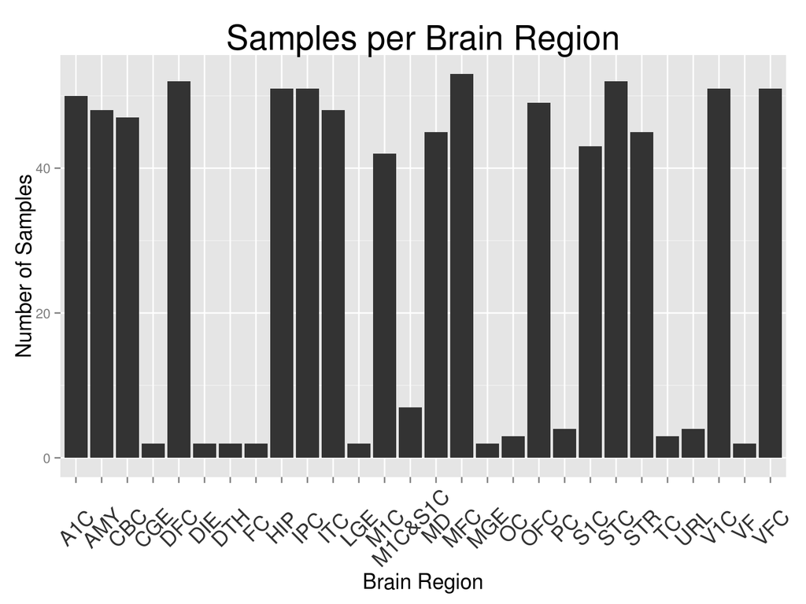

```r
pheno_gene <- read.delim(file.path(metaDir, 'brainspan_samples_metadata.txt'), row.names=1)
meta_donor <- read.delim(file.path(metaDir, 'brainspan_donor_metadata.txt'), row.names=1)

# Subset data by region and hemisphere
meta_ofc <- pheno_gene[which(pheno_gene$BrainRegion == "OFC" & pheno_gene$Hemisphere == "R"),]
meta_ofc$PMI <- as.numeric(as.character(meta_ofc$PMI))
meta_ofc$Stage <- factor(meta_ofc$Stage)
# meta_amy <- pheno_gene[which(pheno_gene$BrainRegion == "AMY" & pheno_gene$Hemisphere == "R"),]

region <- group_by(pheno_gene, BrainRegion)
donors <- summarise(region, donors=n_distinct(BrainCode))
ggplot(donors, aes(x=BrainRegion, y=donors)) +
  geom_bar() +
  ggtitle('Samples per Brain Region') +
  xlab('Brain Region') +
  ylab('Number of Samples') +
  theme(axis.text.x = element_text(colour="grey20",size=15,angle=45,hjust=.5,vjust=.5,face="plain"),
        plot.title = element_text(size = rel(2.0)),
        axis.title = element_text(size = rel(1.25)))
```

## Metadata exploration: focus for now OFC

Phenotype data is loaded in from which we can isolate our brain region of interest. In total there are 57 donors, from which multiple brain regions were sampled.

Exploring the metadata for consistency, and generating a quick overview:

```r
# Age table
age.table <-as.character(unique(meta_donor$Period))
age.table <- strsplit(age.table, ",")
age.table <- do.call("rbind", age.table)
row.names(age.table) <- rep("", nrow(age.table))
colnames(age.table) <- c("Stage", "Description")
kable(data.frame(age.table), format="markdown", row.names=FALSE)
```

| Stage | Description |
| --- | --- |
| 1 | Embryonic |
| 2 | Early fetal |
| 3 | Early fetal |
| 4 | Early mid-fetal |
| 5 | Early mid-fetal |
| 6 | Late mid-fetal |
| 7 | Late fetal |
| 8 | Neonatal and early infancy |
| 9 | Late infancy |
| 10 | Early childhood |
| 11 | Middle and late childhood |
| 12 | Adolescence |
| 13 | Young adulthood |
| 14 | Middle adulthood |
| 15 | Late adulthood |

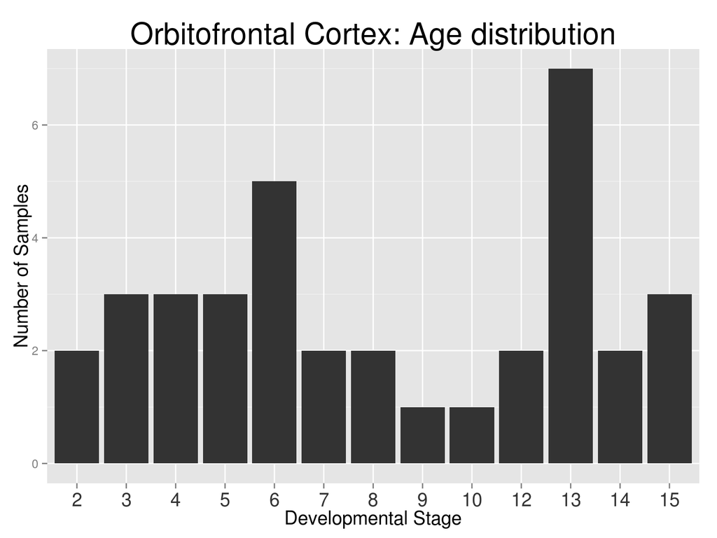

```r
# Age distribution
ggplot(meta_ofc, aes(Stage)) +
  geom_bar() +
  ggtitle('Orbitofrontal Cortex: Age distribution') +
  xlab('Developmental Stage') +
  ylab('Number of Samples') +
  theme(axis.text.x = element_text(colour="grey20",size=15,angle=0,hjust=.5,vjust=.5,face="plain"),
        plot.title = element_text(size = rel(2.0)),
        axis.title = element_text(size = rel(1.25)))
```

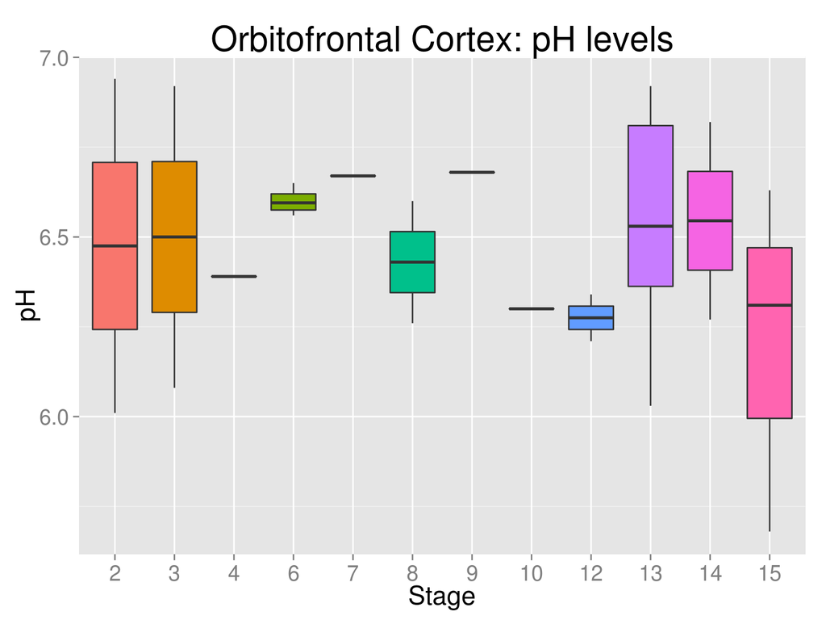

```r
# pH measurements
ggplot(na.omit(meta_ofc), aes(x=Stage, y=pH, fill=Stage)) +
  geom_boxplot() +
  ggtitle('Orbitofrontal Cortex: pH levels') +
  xlab('Stage') +
  guides(fill=FALSE) +
  theme(plot.title = element_text(size = rel(2.0)),
        axis.title = element_text(size = rel(1.5)),
        axis.text = element_text(size = rel(1.25)))
```

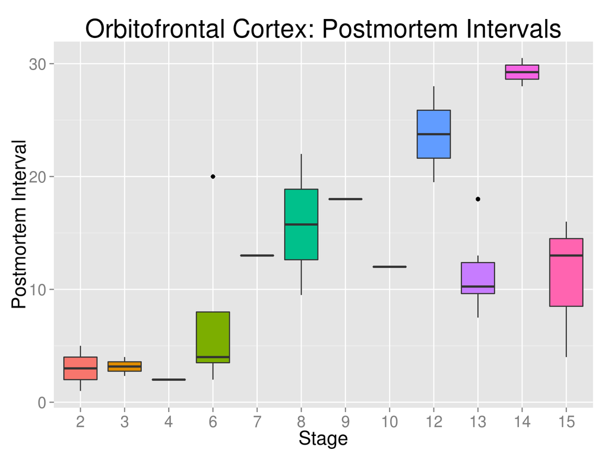

```r
# Time between death and sample collection; remove non-numeric values
ggplot(na.omit(meta_ofc), aes(x=Stage, y=PMI, fill=Stage)) +
  geom_boxplot() +
  ggtitle('Orbitofrontal Cortex: Postmortem Intervals') +
  xlab('Stage') +
  ylab('Postmortem Interval') +
  guides(fill=FALSE) +
  theme(legend.position="none",
        plot.title = element_text(size = rel(2.0)),
        axis.title = element_text(size = rel(1.5)),
        axis.text = element_text(size = rel(1.25)))
```

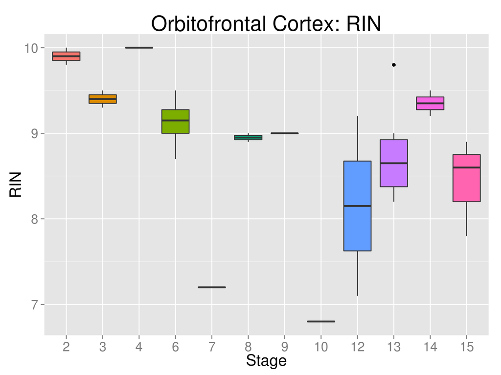

```r
# RNA Integrity
ggplot(na.omit(meta_ofc), aes(x=Stage, y=RIN, fill=Stage)) +
  geom_boxplot() +
  ggtitle('Orbitofrontal Cortex: RIN') +
  xlab('Stage') +
  ylab('RIN') +
  guides(fill=FALSE) +
  theme(legend.position="none",
        plot.title = element_text(size = rel(2.0)),
        axis.title = element_text(size = rel(1.5)),
        axis.text = element_text(size = rel(1.25)))
```

As we have seen with the Braincloud data, there is a positive correlation observed with devleopmental stage and PMI and a negative correlations with RIN. Not surprising, fetal samples are more likely to have been obtained faster. The authors also acknolwedge this in the manuscript and account for it by incorporating both as covariates in the model.

## Quality Control on normalized data

ArrayQualityMetrics QC report for GSE25219

```r
 arrayQualityMetrics(expressionset=eset.ofc, intgroup=c('fetal'),
                     outdir='./results/report_OFC', force=TRUE,  do.logtransform=FALSE)
```

## Clustering of normalized data

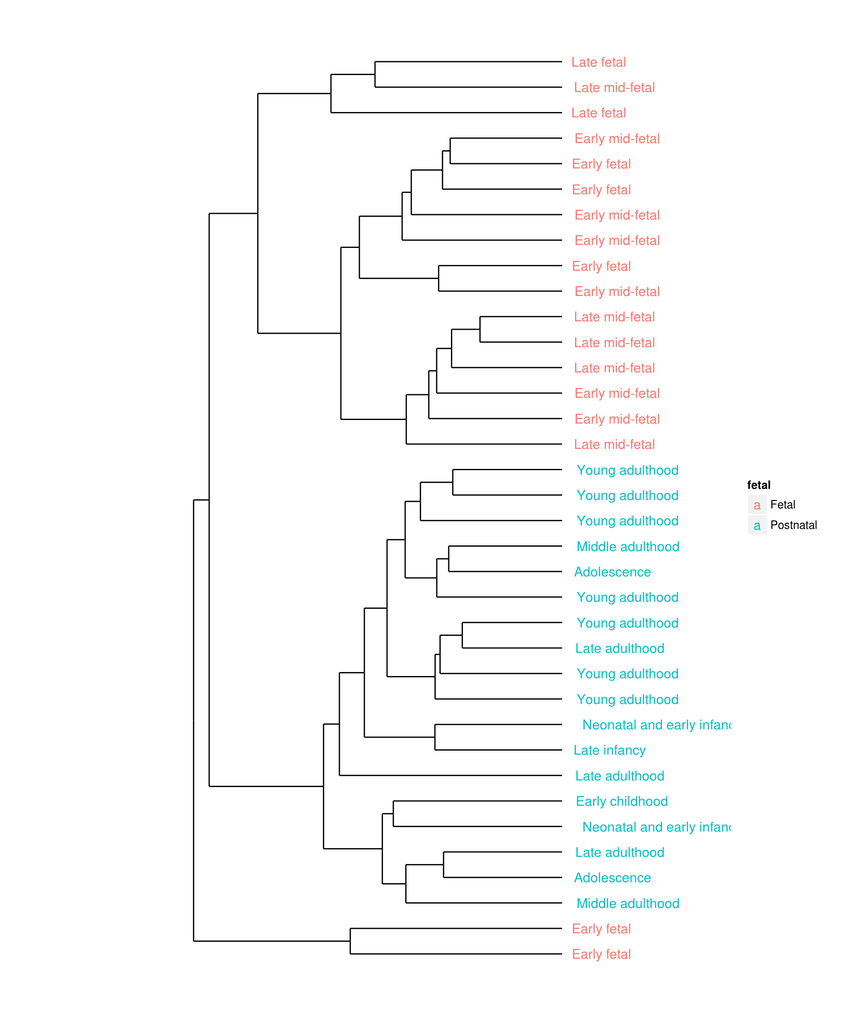

A false color heatmap of the distance between arrays demonstrates a high degree of similarity among fetal samples and likewise with non-fetal samples. Two fetal samples cluster with postnatal, similar to dendorgram above. Remove these samples.

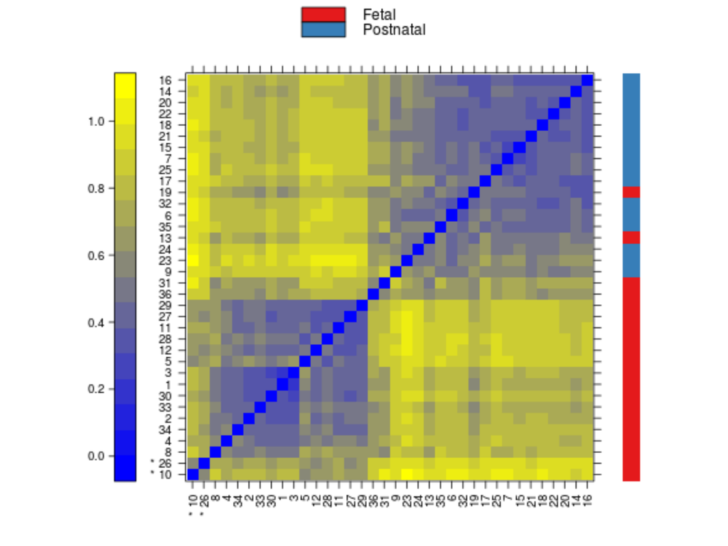

Density plots (smoothed histograms) for all arrays follow a similar distribution shape and range. The shape of distribution is questionable with a fairly heavy right tail.

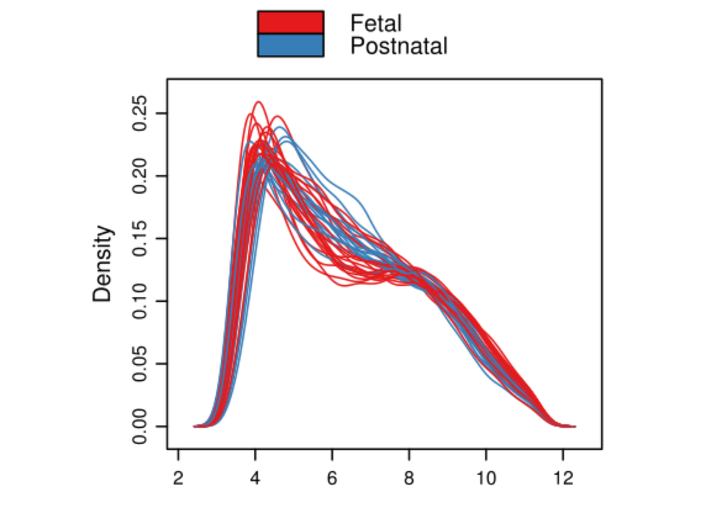

## Quick check with raw data

Try checking the quality on a handful of .CEL files and see if we see the same distribution. If not, it might be better to work directly from .CEL files.

Reading in : ./data/geo_march2014/CEL/GSM703924_HSB92-OFC-R.CEL.gz Reading in : ./data/geo_march2014/CEL/GSM703972_HSB97-OFC-R.CEL.gz Reading in : ./data/geo_march2014/CEL/GSM704048_HSB100-OFC-R.CEL.gz Reading in : ./data/geo_march2014/CEL/GSM704080_HSB102-OFC-R.CEL.gz Reading in : ./data/geo_march2014/CEL/GSM704110_HSB103-OFC-R.CEL.gz

|  | SampleName | BrainCode | BrainRegion | Hemisphere | Sex | Age | Stage | PMI | pH | RIN |
| --- | --- | --- | --- | --- | --- | --- | --- | --- | --- | --- |
| GSM703924 | HSB92_OFC_R | HSB92 | OFC | R | M | 21 PCW | 6 | 4 | 6.65 | 9.1 |
| GSM703972 | HSB97_OFC_R | HSB97 | OFC | R | F | 17 PCW | 5 | 1 | NA | 9.9 |
| GSM704048 | HSB100_OFC_R | HSB100 | OFC | R | F | 19 PCW | 6 | 4 | 6.56 | 9.5 |
| GSM704080 | HSB102_OFC_R | HSB102 | OFC | R | F | 21 PCW | 6 | >13 | 5.89 | 9.4 |
| GSM704110 | HSB103_OFC_R | HSB103 | OFC | R | M | 13 PCW | 4 | 1.5 | NA | 9.3 |

### QC raw data: pre-normalization

The raw data seems better than what we obtained from GEO, with higher signal intensities. Two samples show a slightly wider distribution and another is skewed to the left. Will check how this changes after normalization.

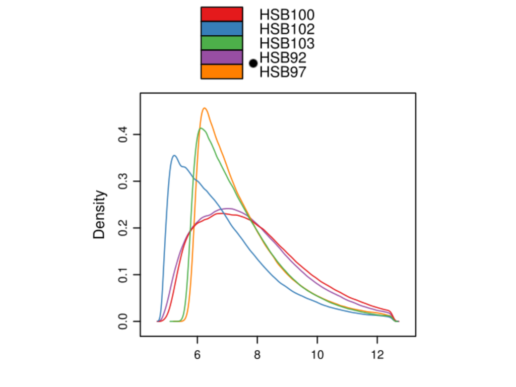

The data was normalized for differential gene expression analysis using Robust Multichip Average (RMA) in the oligo BioConductor package. Here, RMA normalizes the intensity values at the probe level, and collapses probes into “core” transcripts based on annotations provided by Affymetrix.

```r
geneSummaries <- rma(affyRaw, target="core", background=T, normalize=T)
```

### QC raw data: post-normalization

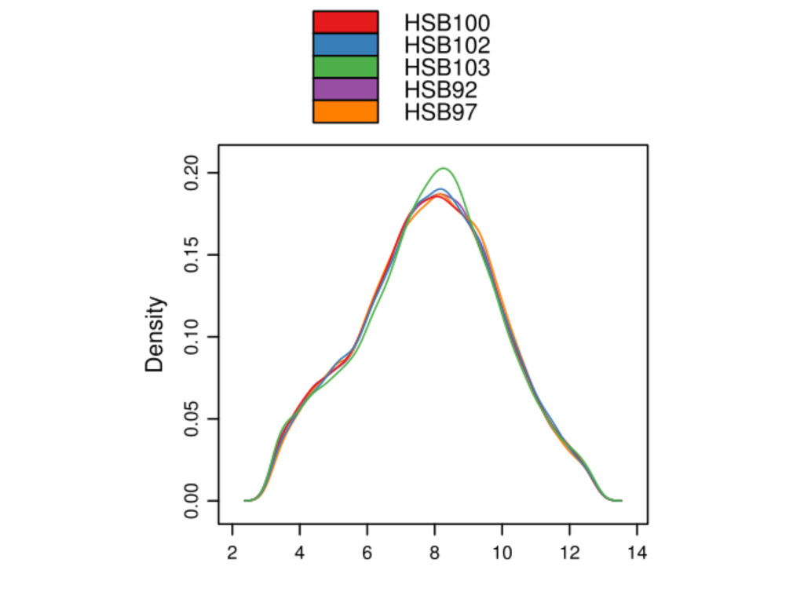

## A simple linear model fit including RIN and PMI as covariates

In the Kang et al study, age was evaluated using ANOVA and both RIN and PMI were included as covariates. To stay consistent, we performed an ANCOVA the same on Orbitofrontal cortex data, modeling Age/Developemental Stage as a continuous variable.

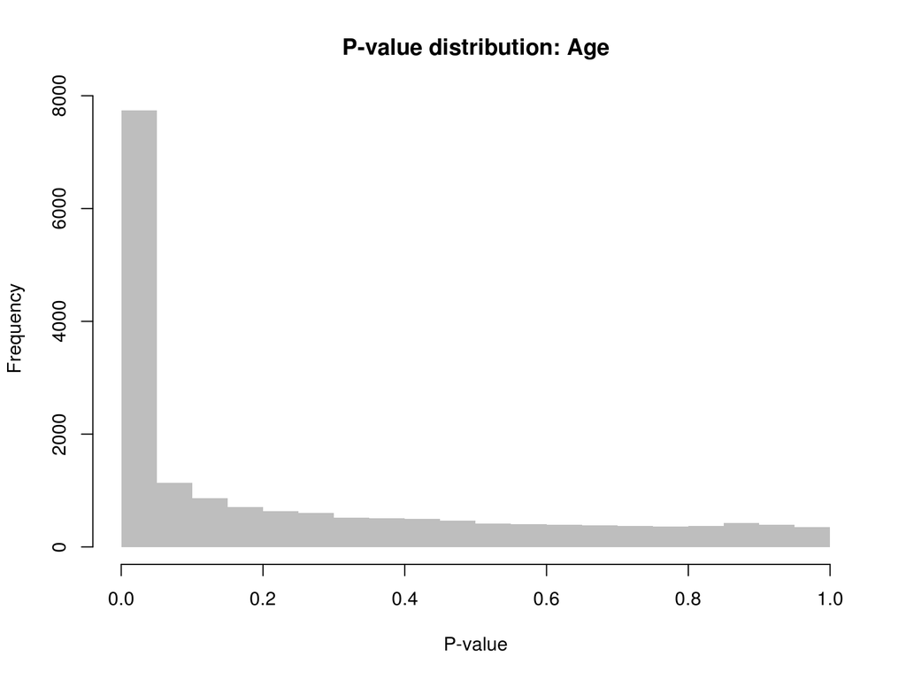

```r
# Remove outlier samples
remove <- c(which(label(ddata)$x == 1), which(label(ddata)$x == 2))

# Remove NA values
meta_new <- meta_new[-remove,]
meta_new <- meta_new[which(!is.na(meta_new$PMI)),]
data_new <- exprs(eset.ofc)[,rownames(meta_new)]

# Update expression set
exprs(eset.ofc) <-data_new
pData(eset.ofc) <- meta_new

# Model fit
mod<-model.matrix(~Stage + PMI + RIN, pData(eset.ofc))
fit<-lmFit(eset.ofc, mod)
fit<-eBayes(fit)

topStage<-topTable(fit,coef=2,number=nrow(exprs(eset.ofc)), adjust.method="BH")
hist(topStage$P.Value, col="grey", border=F, main="P-value distribution: Age", xlab="P-value")
```

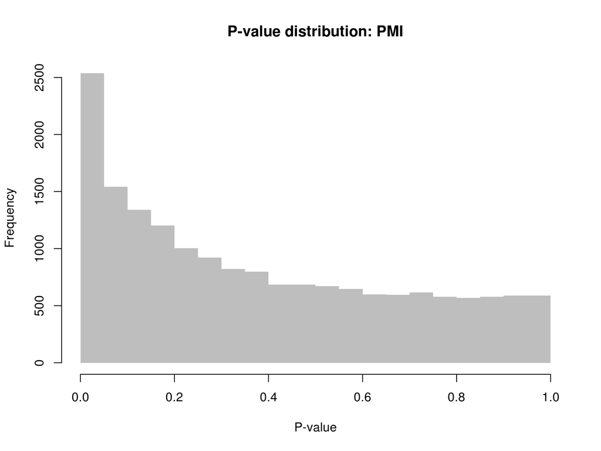

```r
topPMI<-topTable(fit,coef=3,number=nrow(exprs(eset.ofc)), adjust.method="BH")
hist(topPMI$P.Value, col="grey", border=F, main="P-value distribution: PMI", xlab="P-value")
```

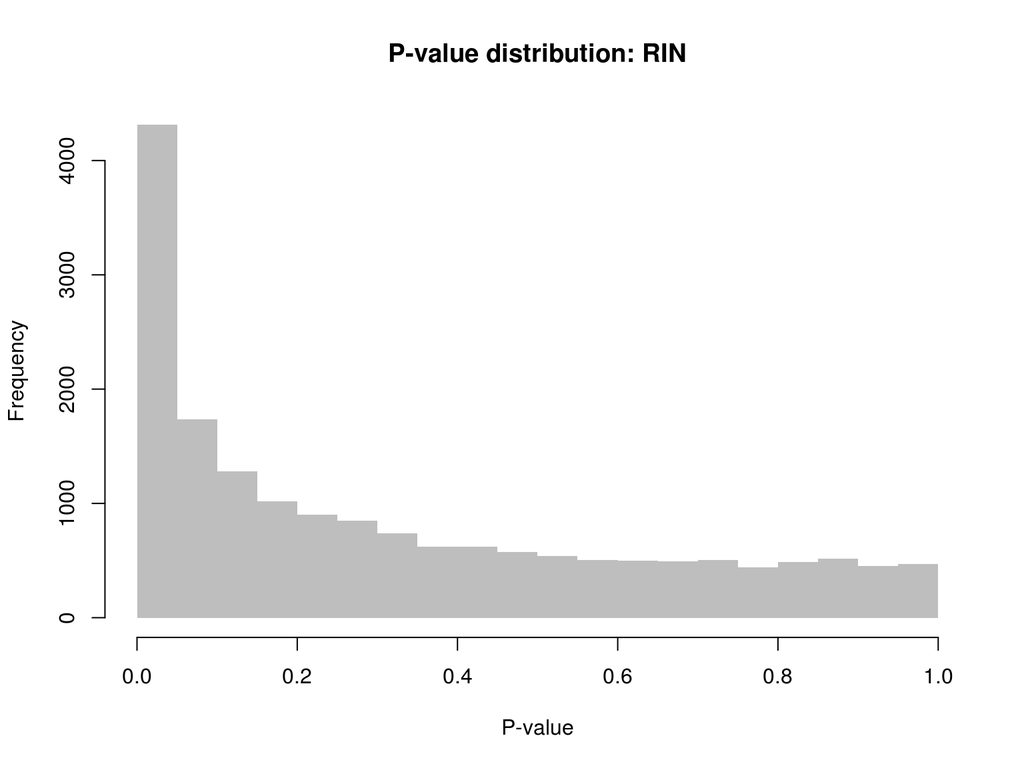

```r
topRIN<-topTable(fit,coef=4,number=nrow(exprs(eset.ofc)), adjust.method="BH")
hist(topRIN$P.Value, col="grey", border=F, main="P-value distribution: RIN", xlab="P-value")
```

Alot of differentially expressed genes with Age/Developemntal Stage (3020) even at a quite stringent threshold (padj < 0.001). Suprisingly few significant changes associated with RIN (880) and none associated with postmortem interval.

## Developmental expression changes also identify with PMI and RIN

Take the top 6 probes that are affected by age, and plot these values against age, PMI and RIN. Although the changes are not identical, we still see a similarity in the trend as we did with the Braincloud data. This indicates that factors need to be better corrected for to ensure we are identifying expression changes truly associated with development.

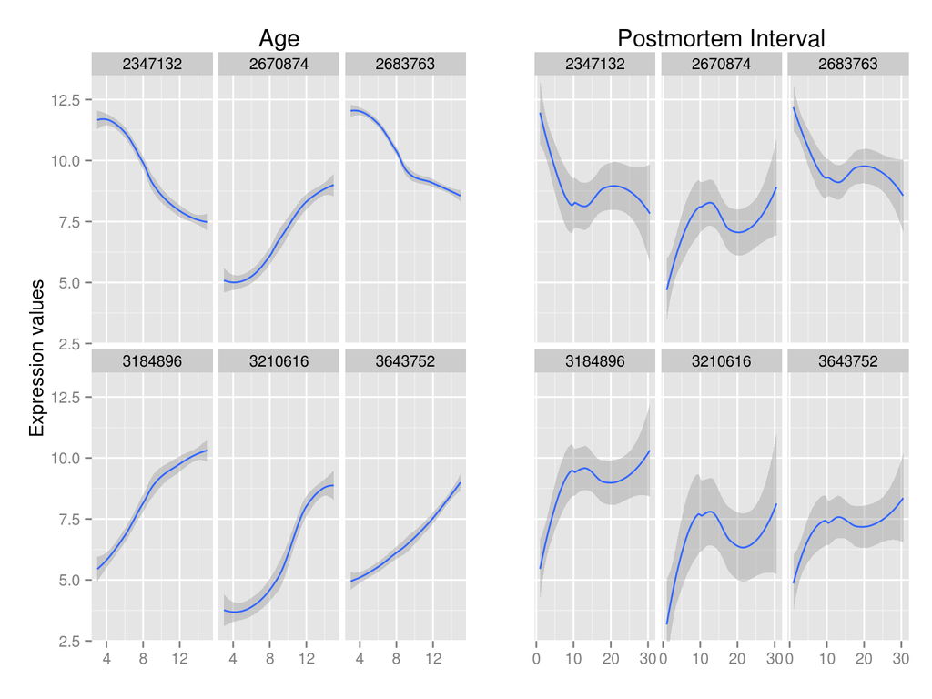

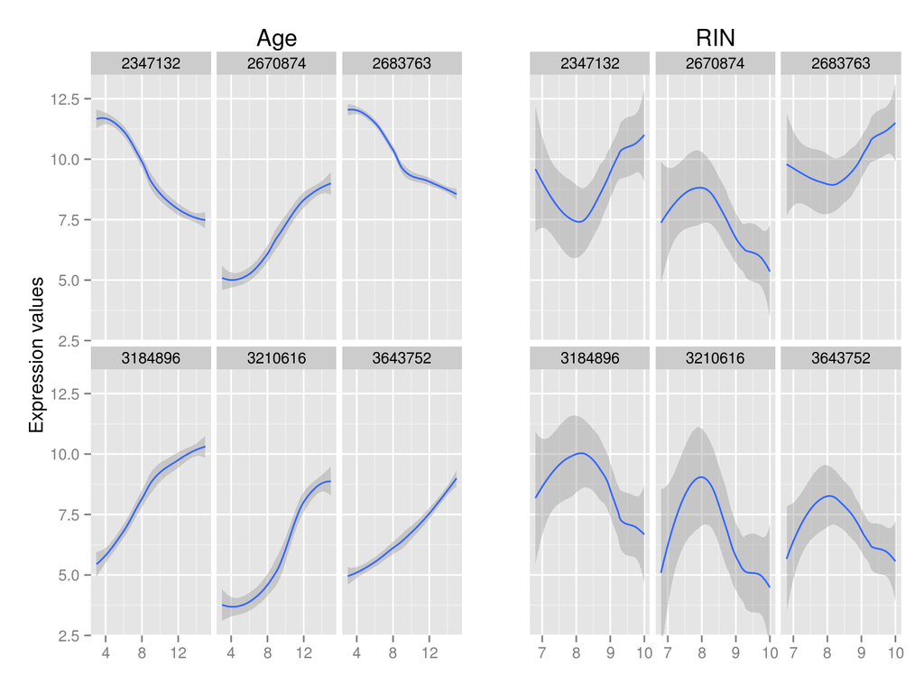